# Starwars Network Analysis

Rafaela Becerra

## Packages needed

```r
library(igraph)
```

## Load the Star Wars network created.

```r
setwd("C:/Users/Rafaela Becerra/Desktop/UC3M/Network_Analysis/Assignments/Starwars")
sw.network <- read_graph('sw.net.txt', format='gml')
```

## Order and size of the network.

```r
go<- gorder(sw.network)
print(paste('The order is: ',go))
```

```
## [1] "The order is:  111"
```

```r
gs<- gsize(sw.network)
print(paste('The size is: ',gs))
```

```
## [1] "The size is:  444"
```

## Induced subgraph that includes the following characters:

- DARTH VADER (number 1 of the list of vertices),
- R2-D2 (2),
- CHEWBACCA (3),
- OBI-WAN (9),
- EMPEROR (13),
- C-3PO (25),
- JABBA (30),
- GREEDO (31),
- YODA (35),
- BOBA FETT (49),
- BERU (52),
- CAPTAIN ANTILLES (66),
- LUKE (67),
- CAMIE (68),
- BIGGS (69),
- LEIA (70),
- MOTTI (71),
- TARKIN (72),
- HAN (73),
- DODONNA (74),
- GOLD LEADER (75),
- WEDGE (76),
- RED LEADER (77),
- RED TEN (78),
- GOLD FIVE (79),
- RIEEKAN (80),
- DERLIN (81),
- ZEV (82),
- PIETT (83),
- OZZEL (84),
- DACK (85),
- JANSON (86),
- NEEDA (87),
- LANDO (88),
- JERJERROD (89),
- BIB FORTUNA (90),
- BOUSHH (91), and
- ADMIRAL ACKBAR (92).

```r
include_v <- c(1,2,3,9,13,25,30,31,35,49,52,66, 67, 68,69, 70, 71:92)
induced.1 <- induced_subgraph(sw.network, include_v)
induced.1
```

```
## IGRAPH 0aa0fa4 UNW- 38 126 --
## + attr: id (v/n), name (v/c), value (v/n), colour (v/c), weight (e/n)
## + edges from 0aa0fa4 (vertex names):
##  [1] DARTH VADER--R2-D2     DARTH VADER--CHEWBACCA R2-D2      --CHEWBACCA
##  [4] DARTH VADER--OBI-WAN   R2-D2      --OBI-WAN   CHEWBACCA  --OBI-WAN
##  [7] DARTH VADER--EMPEROR   R2-D2      --EMPEROR   OBI-WAN    --EMPEROR
## [10] DARTH VADER--C-3PO     R2-D2      --C-3PO     CHEWBACCA  --C-3PO
## [13] OBI-WAN    --C-3PO     EMPEROR    --C-3PO     DARTH VADER--JABBA
## [16] R2-D2      --JABBA     CHEWBACCA  --JABBA     C-3PO      --JABBA
## [19] DARTH VADER--GREEDO    DARTH VADER--YODA      R2-D2      --YODA
## [22] OBI-WAN    --YODA      EMPEROR    --YODA      C-3PO      --YODA
## + ... omitted several edges
```

## Order and size of the induced subgraph.

```r
go<- gorder(induced.1)
print(paste('The order is: ',go))
```

```
## [1] "The order is:  38"
```

```r
gs<- gsize(induced.1)
print(paste('The size is: ',gs))
```

```
## [1] "The size is:  126"
```

## Basic visual representation of such subgraph.

```r
vertex_attr_names(induced.1)
```

```
## [1] "id"     "name"   "value"  "colour"
```

```r
edge_attr(induced.1)
```

```
## $weight
##   [1] 32  2 17 47 28  6 21  5  5 11 55 39  9  2  1  4  3  3  1  9  5 20  2  1  3
##  [26]  2  1  1  1  1  3  1  1  8 34 32 22  3 29  2  6  3  2  1  1  4  2  2 23 48
##  [51]  1 49  1  1 26  1  1  1  7  1  2  2 18 77 10 54  1  1  1 43 69  1  1  1  1
##  [76]  4  2  1  1  1  3  3  1  1  3  1  1  1  1  4  3  1  1  1  1  8  1  2  2  3
## [101]  2  1  1  4  5 20  8  2  6 12 12  6  1  2  1  1  2  1  1  1  2  1  2  2  1
## [126]  5
```

[figure not shown]

```r
la <- layout_in_circle(induced.1)
#Graph display of the network.
plot.igraph(induced.1,
            vertex.label=V(induced.1)$name,
            layout=la,
            edge.color="lightblue",
            vertex.size=5,
            vertex.label.dist=1,
            edge.width=E(induced.1)$weight/10,
            vertex.label.color="black",
            vertex.label.cex=0.5,
            vertex.color="blue",
            vertex.size=15)
```

By this graph we can see a graphical representation of a prespecified subset of the vertices of the network. In this case, we have determined the width of the edges as the weights or the number of scenes in which the characters of the vertices appear together. As display, Gold Five appears alone in all of the episodes, conversely, Han with Chewbacca seems to be a repetitive duo on the scenes. Also, with major appearences together are Han with C-3PO, Luke or Leia, and other combinations like Luke and R2-D2, Leia and Chewbacca, or Leia and C-3PO.

## Induced subgraph composed by the other characters.

```r
ninclude_v <- subset(seq(1:111), !(seq(1:111) %in% include_v))
induced.2 <- induced_subgraph(sw.network, ninclude_v)
induced.2
```

```
## IGRAPH 0b1b2d9 UNW- 73 162 --
## + attr: id (v/n), name (v/c), value (v/n), colour (v/c), weight (e/n)
## + edges from 0b1b2d9 (vertex names):
##  [1] BB-8          --POE           BB-8          --LOR SAN TEKKA
##  [3] BB-8          --REY           BB-8          --UNKAR PLUTT
##  [5] BB-8          --FINN          BB-8          --BALA-TIK
##  [7] BB-8          --MAZ           QUI-GON       --NUTE GUNRAY
##  [9] PK-4          --TC-14         QUI-GON       --TC-14
## [11] NUTE GUNRAY   --TC-14         NUTE GUNRAY   --DOFINE
## [13] TC-14         --DOFINE        NUTE GUNRAY   --RUNE
## [15] RUNE          --TEY HOW       NUTE GUNRAY   --TEY HOW
## + ... omitted several edges
```

```r
go<- gorder(induced.2)
print(paste('The order is: ',go))
```

```
## [1] "The order is:  73"
```

```r
gs<- gsize(induced.2)
print(paste('The size is: ',gs))
```

```
## [1] "The size is:  162"
```

```r
vertex_attr_names(induced.2)
```

```
## [1] "id"     "name"   "value"  "colour"
```

```r
edge_attr(induced.2)
```

```
## $weight
##   [1]  8  2 17  1 15  1  3  1  1  1  1  1  1  8  2  1  3 22  2  2  2  2  1  7  2
##  [26]  9  7 16  1  1  2  2 10  6  3  2  2  2  2  1  3  8  5  1  1  2  1  2  1  1
##  [51]  1  2  1  1  1  1  2  2  1  4  1  1  1  2  3  1  1  1  1  4  1  2  1  2  2
##  [76]  1  2  1  1  1  2  1  1  1  1  2  1  4  2  2  1  1  1  1  1  2  1  3  1  2
## [101]  2  2  1  1  1  1  1  2  1  5  2  2  1  2  2  1  2  1  1  2  1  1  1  3  1
## [126]  2  1  1  1  3  5  2 11  1  2  1 29  1  1  3  2  2  2  4  2  1  1  1  1  1
## [151]  3  1  2  2  1  2  2  1  2  2  1  1
```

[figure not shown]

```r
la <- layout_in_circle(induced.2)
#Graph display of the network.
plot.igraph(induced.2,
            vertex.label=V(induced.2)$name,
            layout=la,
            edge.color="lightgreen",
            vertex.size=5,
            vertex.label.dist=1,
            edge.width=E(induced.2)$weight/5,
            vertex.label.color="black",
            vertex.label.cex=0.4,
            vertex.color="green",
            vertex.size=15)
```

[figure not shown]

```r
la <- layout_nicely(induced.2)
#Graph display of the network.
plot.igraph(induced.2,
            vertex.label=V(induced.2)$name,
            layout=la,
            edge.color="lightgreen",
            vertex.size=5,
            vertex.label.dist=1,
            edge.width=E(induced.2)$weight/5,
            vertex.label.color="black",
            vertex.label.cex=0.4,
            vertex.color="green",
            vertex.size=15)
```

We can determine three groups in this subgraph which englobe one, characters that do not interact with other characters in the group at all, and two, groups that contain characters that interact within other characters in the same group but not with the other groups.

Moreover, the number of edges is not equal to the total, consequently, we are sure that there are interactions between this second subgraph and the first display in blue.

The difference between the total number of edges of the network minus the edges of each subgraph will be the number of edges joining the vertices between the two subgraphs.

```r
gs<- gsize(sw.network)-gsize(induced.2)-gsize(induced.1)
print(paste('The number of edges joining the vertices between the subgraphs is: ',gs))
```

```
## [1] "The number of edges joining the vertices between the subgraphs is:  156"
```

```r
print('The number of neighbors or adjacent vertices of (1) is: ')
```

```
## [1] "The number of neighbors or adjacent vertices of (1) is: "
```

```r
neighbors(sw.network,1)
```

```
## + 52/111 vertices, named, from 0a74ff3:
##  [1] R2-D2                CHEWBACCA            QUI-GON
##  [4] NUTE GUNRAY          OBI-WAN              EMPEROR
##  [7] CAPTAIN PANAKA       SIO BIBBLE           JAR JAR
## [10] BOSS NASS            PADME                RIC OLIE
## [13] WATTO                SEBULBA              JIRA
## [16] SHMI                 C-3PO                KITSTER
## [19] WALD                 JABBA                GREEDO
## [22] MACE WINDU           KI-ADI-MUNDI         YODA
## [25] RABE                 BAIL ORGANA          BRAVO TWO
## [28] BRAVO THREE          CAPTAIN TYPHO        SOLA
## + ... omitted several vertices
```

```r
print('Their incident edges are: ')
```

```
## [1] "Their incident edges are: "
```

```r
incident(sw.network,1)
```

```
## + 52/444 edges from 0a74ff3 (vertex names):
##  [1] DARTH VADER--R2-D2          DARTH VADER--CHEWBACCA
##  [3] DARTH VADER--QUI-GON        DARTH VADER--NUTE GUNRAY
##  [5] DARTH VADER--OBI-WAN        DARTH VADER--EMPEROR
##  [7] DARTH VADER--CAPTAIN PANAKA DARTH VADER--SIO BIBBLE
##  [9] DARTH VADER--JAR JAR        DARTH VADER--BOSS NASS
## [11] DARTH VADER--PADME          DARTH VADER--RIC OLIE
## [13] DARTH VADER--WATTO          DARTH VADER--SEBULBA
## [15] DARTH VADER--JIRA           DARTH VADER--SHMI
## [17] DARTH VADER--C-3PO          DARTH VADER--KITSTER
## [19] DARTH VADER--WALD           DARTH VADER--JABBA
## + ... omitted several edges
```

## Degree of DARTH VADER (1).

```r
print('The degree of (1) is: ')
```

```
## [1] "The degree of (1) is: "
```

```r
degree(sw.network,1)
```

```
## DARTH VADER
##          52
```

This is the highest if we compare it to the degree of the rest of the characters as we can check below in the degree sequence of the whole network. This means that this character appears with a lot of the other characters in the scenes.

## Degree sequence, the average degree and the degree distribution of the whole network without weights.

- The degree sequence:

```r
degree(sw.network)
```

```
##          DARTH VADER                R2-D2            CHEWBACCA
##                   52                   22                   19
##                 BB-8              QUI-GON          NUTE GUNRAY
##                   12                   27                   16
##                 PK-4                TC-14              OBI-WAN
##                    2                    5                   36
##               DOFINE                 RUNE              TEY HOW
##                    3                    4                    3
##              EMPEROR       CAPTAIN PANAKA           SIO BIBBLE
##                   22                    9                    8
##              JAR JAR              TARPALS            BOSS NASS
##                   24                    1                    6
##                PADME             RIC OLIE                WATTO
##                   34                    7                    6
##              SEBULBA                 JIRA                 SHMI
##                    6                    3                    8
##                C-3PO           DARTH MAUL              KITSTER
##                   35                    4                    9
##                 WALD            FODE/BEED                JABBA
##                    5                    3                   14
##               GREEDO              VALORUM           MACE WINDU
##                    4                    4                   13
##         KI-ADI-MUNDI                 YODA                 RABE
##                    9                   17                    5
##          BAIL ORGANA         GENERAL CEEL            BRAVO TWO
##                   17                    4                    3
##          BRAVO THREE        CAPTAIN TYPHO      SENATOR ASK AAK
##                    3                    6                    7
##         ORN FREE TAA                 SOLA                JOBAL
##                    3                    4                    4
##                RUWEE              TAUN WE              LAMA SU
##                    4                    4                    2
##            BOBA FETT           JANGO FETT                 OWEN
##                   10                    4                    7
##                 BERU               CLIEGG          COUNT DOOKU
##                    8                    5                   10
##              SUN RIT               POGGLE             PLO KOON
##                    6                    6                    1
##             ODD BALL     GENERAL GRIEVOUS             FANG ZAR
##                    2                    3                    4
```

[output cut: 19 more lines]

```
##                   11                    1                    3
##               BOUSHH       ADMIRAL ACKBAR        LOR SAN TEKKA
##                    4                   11                    4
##                  POE             KYLO REN       CAPTAIN PHASMA
##                   16                   10                    7
##                 FINN          UNKAR PLUTT                  REY
##                   14                    2                   10
##          GENERAL HUX    LIEUTENANT MITAKA             BALA-TIK
##                    5                    2                    5
##                SNOKE                  MAZ                 SNAP
##                    2                    5                    8
##      ADMIRAL STATURA            YOLO ZIFF        COLONEL DATOO
##                    7                    4                    1
##            ELLO ASTY                 JESS              NIV LEK
##                    4                    5                    4
```

```r
#Check that it is twice the size graph
sum(degree(sw.network))
```

```
## [1] 888
```

- The average degree:

```r
mean(degree(sw.network))
```

```
## [1] 8
```

- Degree distribution

Frquency table

```r
table(degree(sw.network))
```

```
##
##  0  1  2  3  4  5  6  7  8  9 10 11 12 13 14 16 17 19 22 24 25 26 27 34 35 36
##  1  8 12 13 20  9  6  6  6  3  5  2  1  1  2  2  2  1  2  1  1  2  1  1  1  1
## 52
##  1
```

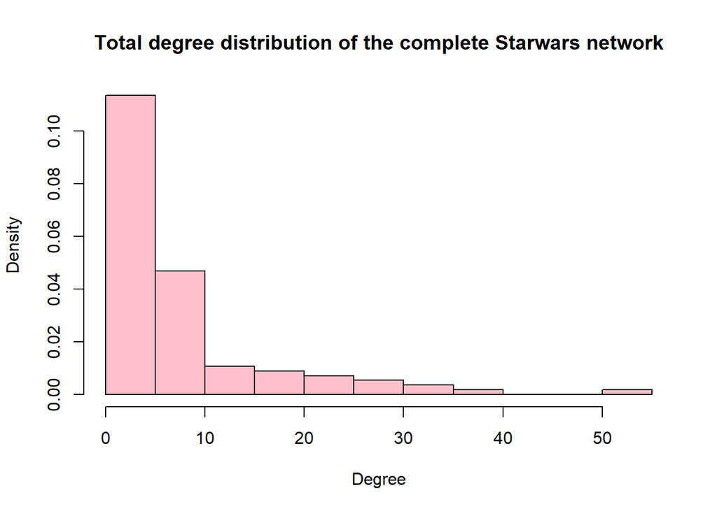

```r
hist(degree(sw.network,mode="total"),
     col="pink",
     main="Total degree distribution of the complete Starwars network",
     xlab="Degree",
     freq=FALSE)
```

Degree distribution

```r
degree_distribution(sw.network)
```

```
##  [1] 0.009009009 0.072072072 0.108108108 0.117117117 0.180180180 0.081081081
##  [7] 0.054054054 0.054054054 0.054054054 0.027027027 0.045045045 0.018018018
## [13] 0.009009009 0.009009009 0.018018018 0.000000000 0.018018018 0.018018018
## [19] 0.000000000 0.009009009 0.000000000 0.000000000 0.018018018 0.000000000
## [25] 0.009009009 0.009009009 0.018018018 0.009009009 0.000000000 0.000000000
## [31] 0.000000000 0.000000000 0.000000000 0.000000000 0.009009009 0.009009009
## [37] 0.009009009 0.000000000 0.000000000 0.000000000 0.000000000 0.000000000
## [43] 0.000000000 0.000000000 0.000000000 0.000000000 0.000000000 0.000000000
## [49] 0.000000000 0.000000000 0.000000000 0.000000000 0.009009009
```

- Plot of the distribution

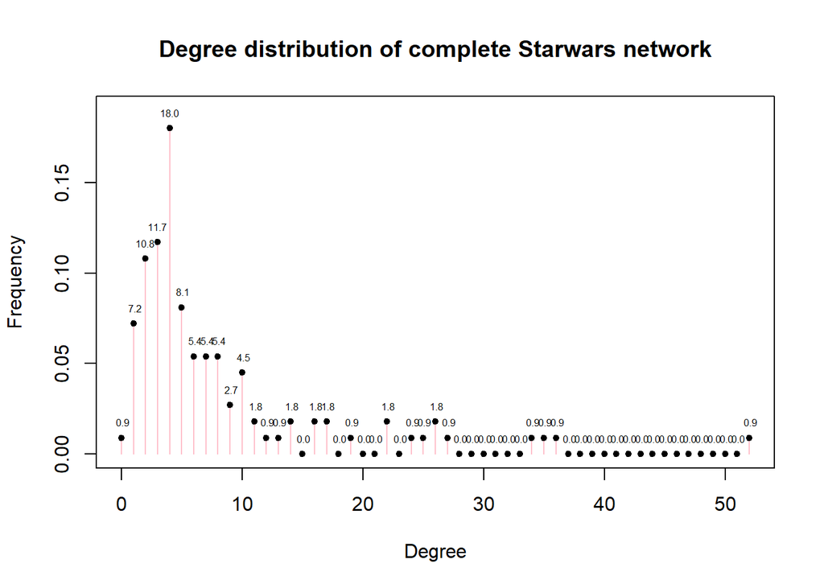

```r
plot(0:max(degree(sw.network)),
     degree_distribution(sw.network),
     ylim=c(0,(max(degree_distribution(sw.network))+0.01)),
     col="pink",
     main="Degree distribution of complete Starwars network",
     xlab="Degree",
     ylab="Frequency",
     type="h")
points(0:max(degree(sw.network)),
       degree_distribution(sw.network),
       pch=20)
text(0:max(degree(sw.network)),
     degree_distribution(sw.network),
     labels=format(100*degree_distribution(sw.network), digits=2), cex=0.5, font=1, pos=3)
```

The degree corresponds to the number of edges incident on a vertex, which in this case corresponds to the number of characters among all which interacted in the scenes of the 1 to seven episodes of Starwars with this certain character represented by this vertex.

Now, we can see that Darth Vader appears with almost half of the characters in the scenes, consequently, is the character whith the highest degree.

After, plotting the distribution of the degrees, which is constructed by the probabilities that a selected vertex in the network has a degree d in a range of degrees, we can see the skewed distribution, as most of the characters just had interactions in the scenes with fewer characters and the results with more than 10 characters are given by just one or two of them.

## Degree sequence, the average degree and the degree distribution of the whole network with weights.

- The degree sequence with weights:

```r
strength(sw.network)
```

```
##          DARTH VADER                R2-D2            CHEWBACCA
##                  309                  279                  297
##                 BB-8              QUI-GON          NUTE GUNRAY
##                   72                  152                   34
##                 PK-4                TC-14              OBI-WAN
##                    2                    5                  261
##               DOFINE                 RUNE              TEY HOW
##                    3                   14                    4
##              EMPEROR       CAPTAIN PANAKA           SIO BIBBLE
##                   84                   41                   12
##              JAR JAR              TARPALS            BOSS NASS
##                   95                    2                   10
##                PADME             RIC OLIE                WATTO
##                  173                   18                   19
##              SEBULBA                 JIRA                 SHMI
##                   10                    5                   28
##                C-3PO           DARTH MAUL              KITSTER
##                  310                    8                   13
##                 WALD            FODE/BEED                JABBA
##                    7                    4                   22
##               GREEDO              VALORUM           MACE WINDU
##                    4                    5                   53
##         KI-ADI-MUNDI                 YODA                 RABE
##                   17                   82                    5
##          BAIL ORGANA         GENERAL CEEL            BRAVO TWO
##                   49                    4                    8
##          BRAVO THREE        CAPTAIN TYPHO      SENATOR ASK AAK
##                    5                   11                    8
##         ORN FREE TAA                 SOLA                JOBAL
##                    4                    5                    5
##                RUWEE              TAUN WE              LAMA SU
##                    6                   10                    8
##            BOBA FETT           JANGO FETT                 OWEN
##                   17                    6                   22
##                 BERU               CLIEGG          COUNT DOOKU
##                   15                    8                   19
##              SUN RIT               POGGLE             PLO KOON
##                    8                    8                    1
##             ODD BALL     GENERAL GRIEVOUS             FANG ZAR
##                    4                    4                    7
```

[output cut: 19 more lines]

```
##                   81                    1                    4
##               BOUSHH       ADMIRAL ACKBAR        LOR SAN TEKKA
##                    5                   18                    7
##                  POE             KYLO REN       CAPTAIN PHASMA
##                   46                   25                   10
##                 FINN          UNKAR PLUTT                  REY
##                  113                    3                   87
##          GENERAL HUX    LIEUTENANT MITAKA             BALA-TIK
##                   11                    3                    6
##                SNOKE                  MAZ                 SNAP
##                    5                   13                    9
##      ADMIRAL STATURA            YOLO ZIFF        COLONEL DATOO
##                    9                    4                    1
##            ELLO ASTY                 JESS              NIV LEK
##                    8                    8                    7
```

```r
#Check that it is twice the size graph
sum(strength(sw.network))
```

```
## [1] 4184
```

- The average degree with weights:

```r
mean(strength(sw.network))
```

```
## [1] 37.69369
```

- Degree distribution with weights

Frquency table with weights

```r
table(strength(sw.network))
```

```
##
##   0   1   2   3   4   5   6   7   8   9  10  11  12  13  14  15  17  18  19  20
##   1   5   7   5  14  11   3   4   9   3   5   2   2   4   1   2   2   2   2   1
##  22  25  28  34  41  46  49  53  72  81  82  84  87  95 113 152 173 241 258 261
##   2   1   1   1   1   1   1   1   1   1   1   1   1   1   1   1   1   1   1   1
## 279 297 309 310 360
##   1   1   1   1   1
```

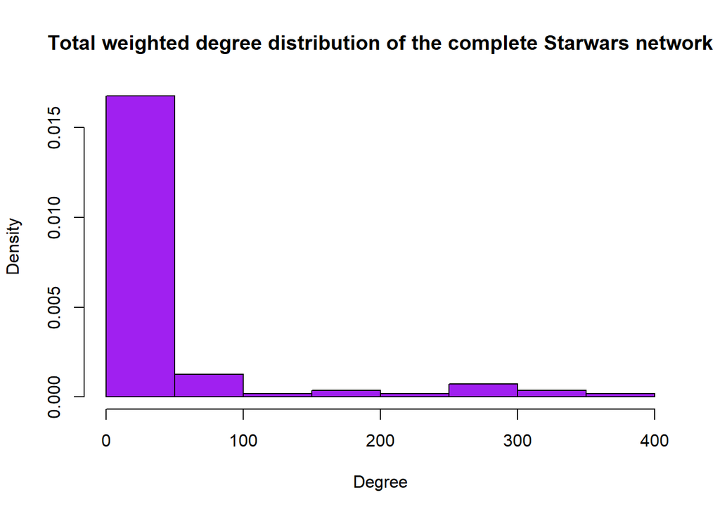

```r
hist(strength(sw.network,mode="total"),
     col="purple",
     main="Total weighted degree distribution of the complete Starwars network",
     xlab="Degree",
     freq=FALSE)
```

Degree distribution with weights

```r
graph_strength_distribution <- function (graph, cumulative = FALSE, ...)
{
  if (!is.igraph(graph)) {
    stop("Not a graph object")
  }
  cs <- graph.strength(graph, ...)
  hi <- hist(cs, -1:max(cs), plot = FALSE)$density
  if (!cumulative) {
    res <- hi
  }
  else {
    res <- rev(cumsum(rev(hi)))
  }
  res
}
graph_strength_distribution(sw.network)
```

```
##   [1] 0.009009009 0.045045045 0.063063063 0.045045045 0.126126126 0.099099099
##   [7] 0.027027027 0.036036036 0.081081081 0.027027027 0.045045045 0.018018018
##  [13] 0.018018018 0.036036036 0.009009009 0.018018018 0.000000000 0.018018018
##  [19] 0.018018018 0.018018018 0.009009009 0.000000000 0.018018018 0.000000000
##  [25] 0.000000000 0.009009009 0.000000000 0.000000000 0.009009009 0.000000000
##  [31] 0.000000000 0.000000000 0.000000000 0.000000000 0.009009009 0.000000000
##  [37] 0.000000000 0.000000000 0.000000000 0.000000000 0.000000000 0.009009009
##  [43] 0.000000000 0.000000000 0.000000000 0.000000000 0.009009009 0.000000000
##  [49] 0.000000000 0.009009009 0.000000000 0.000000000 0.000000000 0.009009009
##  [55] 0.000000000 0.000000000 0.000000000 0.000000000 0.000000000 0.000000000
##  [61] 0.000000000 0.000000000 0.000000000 0.000000000 0.000000000 0.000000000
##  [67] 0.000000000 0.000000000 0.000000000 0.000000000 0.000000000 0.000000000
##  [73] 0.009009009 0.000000000 0.000000000 0.000000000 0.000000000 0.000000000
##  [79] 0.000000000 0.000000000 0.000000000 0.009009009 0.009009009 0.000000000
##  [85] 0.009009009 0.000000000 0.000000000 0.009009009 0.000000000 0.000000000
```

[output cut: 46 more lines]

- Plot of the distribution with weights

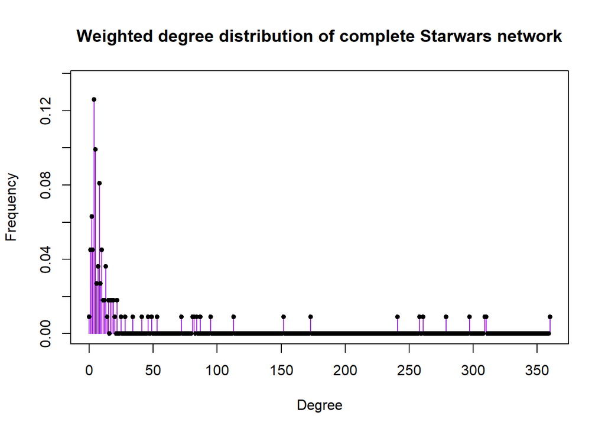

```r
plot(0:max(strength(sw.network)),
     graph_strength_distribution(sw.network),
     ylim=c(0,(max(graph_strength_distribution(sw.network))+0.01)),
     col="purple",
     main="Weighted degree distribution of complete Starwars network",
     xlab="Degree",
     ylab="Frequency",
     type="h")
points(0:max(strength(sw.network)),
       graph_strength_distribution(sw.network),
       pch=20)
```

If we consider the weights or the number of appearences that characters have with each other and not just the relations, we can see that the character with more participation is Han which has 360 scenes with other characters, next we have C-3PO with 310 and Darth Vader with 309. Consequently, even though Darth Vader is the character that appears with more characters, it is not the one that appears the most in these seven episodes. Moreover, the total number of weighted degrees is 4184, these means that we have 2092 connections if we consider the frequency.

Additionally, the average weighted degree is approximately 38, which is much more than the unweighted degree which derives the importance of the frequency in this case. This number represents the number of scenes in average that a character appeared. If we check the histogram and the frequency of the weighted degrees, we can see that there are a lot of characters that have almost no appearences like Colonel Datto, Clone Commander, Tion Medon, etc.

Because of this disparateness on the number of appearances the distribution is still skewed to the right.

## Previous steps for the two induced subgraphs.

## Subgraph 1

## Degree

- The degree sequence:

```r
degree(induced.1)
```

```
##      DARTH VADER            R2-D2        CHEWBACCA          OBI-WAN
##               20               14               11               10
##          EMPEROR            C-3PO            JABBA           GREEDO
##                6               21                8                2
##             YODA        BOBA FETT             BERU CAPTAIN ANTILLES
##                6                8                5                2
##             LUKE            CAMIE            BIGGS             LEIA
##               23                2                8               18
##            MOTTI           TARKIN              HAN          DODONNA
##                3                3               15                3
##      GOLD LEADER            WEDGE       RED LEADER          RED TEN
##                5                8                7                2
##        GOLD FIVE          RIEEKAN           DERLIN              ZEV
##                0                4                2                2
##            PIETT            OZZEL             DACK           JANSON
##                4                2                1                1
##            NEEDA            LANDO        JERJERROD      BIB FORTUNA
##                2               10                1                3
##           BOUSHH   ADMIRAL ACKBAR
##                4                6
```

```r
#Check that it is twice the size graph
sum(degree(induced.1))
```

```
## [1] 252
```

- The average degree:

```r
round(mean(degree(induced.1)))
```

```
## [1] 7
```

- Degree distribution

Frquency table

```r
table(degree(induced.1))
```

```
##
##  0  1  2  3  4  5  6  7  8 10 11 14 15 18 20 21 23
##  1  3  8  4  3  2  3  1  4  2  1  1  1  1  1  1  1
```

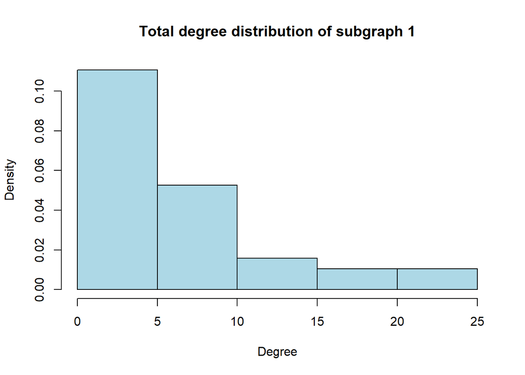

```r
hist(degree(induced.1,mode="total"),
     col="lightblue",
     main="Total degree distribution of subgraph 1",
     xlab="Degree",
     freq=FALSE)
```

Degree distribution

```r
degree_distribution(induced.1)
```

```
##  [1] 0.02631579 0.07894737 0.21052632 0.10526316 0.07894737 0.05263158
##  [7] 0.07894737 0.02631579 0.10526316 0.00000000 0.05263158 0.02631579
## [13] 0.00000000 0.00000000 0.02631579 0.02631579 0.00000000 0.00000000
## [19] 0.02631579 0.00000000 0.02631579 0.02631579 0.00000000 0.02631579
```

- Plot of the distribution

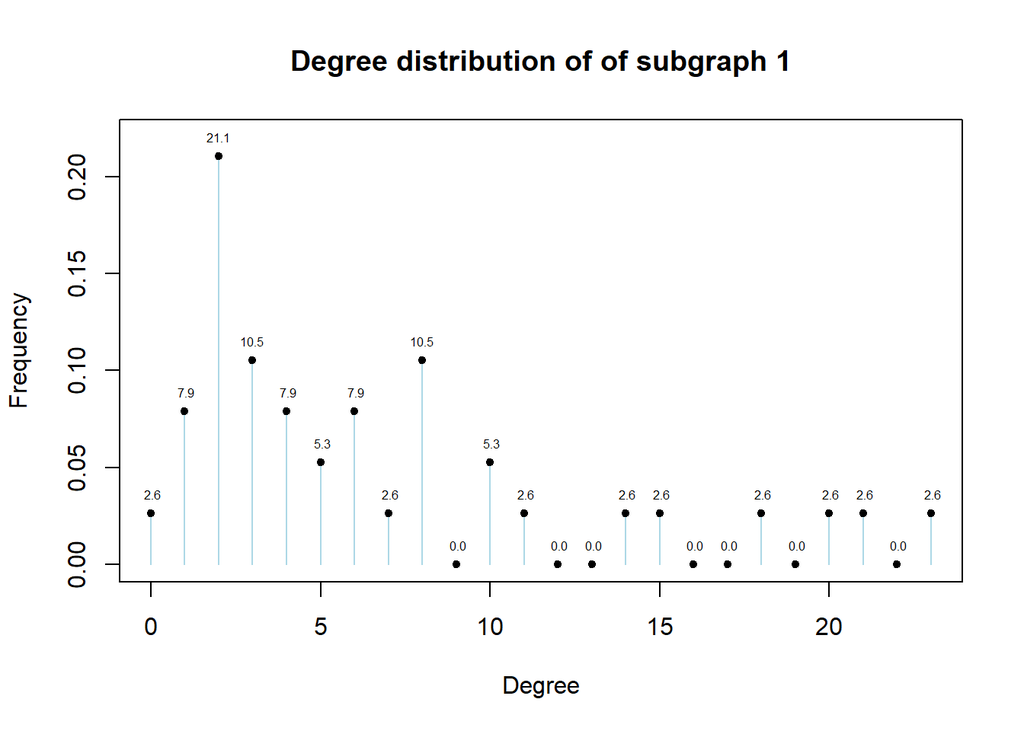

```r
plot(0:max(degree(induced.1)),
     degree_distribution(induced.1),
     ylim=c(0,(max(degree_distribution(induced.1))+0.01)),
     col="lightblue",
     main="Degree distribution of of subgraph 1",
     xlab="Degree",
     ylab="Frequency",
     type="h")
points(0:max(degree(induced.1)),
       degree_distribution(induced.1),
       pch=20)
text(0:max(degree(induced.1)),
     degree_distribution(induced.1),
     labels=format(100*degree_distribution(induced.1), digits=2), cex=0.5, font=1, pos=3)
```

If we take a look at the first subgroup, we can see that in this prespecified subset of the vertices lay 38 characters which create a network with 126 edges or the connections among these characters and represent a total of 28.38%, if we consider the total edges on the whole network.

This subgraph presents an average degree of ,approximately, 7 which is lower that what we got for the complete network (8), this can be attributed to the fact that there are more characters in the other group, consequently, the connections between them are not taken into account. In fact, recall that the number of edges joinning both subgroups are 156.

If we check the frequency table of the degree distribution we see that the media is 2, and that the maximum number is 23, and that as the degree increases there are only ones for each number and a total of 7 characters that appear with more than 10 other characters. If we check the accumulated probability that a random vertex has less or equal to five degrees is more than 50%, so there is a high probability that, when just considering this group, the number of characters that act together is less than for the total network.

## Degree with weights

- The degree sequence with weights:

```r
strength(induced.1)
```

```
##      DARTH VADER            R2-D2        CHEWBACCA          OBI-WAN
##              164              229              247              149
##          EMPEROR            C-3PO            JABBA           GREEDO
##               38              275               16                2
##             YODA        BOBA FETT             BERU CAPTAIN ANTILLES
##               43               12                9                2
##             LUKE            CAMIE            BIGGS             LEIA
##              236                4               15              244
##            MOTTI           TARKIN              HAN          DODONNA
##                4               10              295                3
##      GOLD LEADER            WEDGE       RED LEADER          RED TEN
##                5               20               13                2
##        GOLD FIVE          RIEEKAN           DERLIN              ZEV
##                0                9                2                2
##            PIETT            OZZEL             DACK           JANSON
##               12                4                3                2
##            NEEDA            LANDO        JERJERROD      BIB FORTUNA
##                2               80                1                4
##           BOUSHH   ADMIRAL ACKBAR
##                5               13
```

```r
#Check that it is twice the size graph
sum(strength(induced.1))
```

```
## [1] 2176
```

- The average degree with weights:

```r
mean(strength(induced.1))
```

```
## [1] 57.26316
```

- Degree distribution with weights

Frquency table with weights

```r
table(strength(induced.1))
```

```
##
##   0   1   2   3   4   5   9  10  12  13  15  16  20  38  43  80 149 164 229 236
##   1   1   7   2   4   2   2   1   2   2   1   1   1   1   1   1   1   1   1   1
## 244 247 275 295
##   1   1   1   1
```

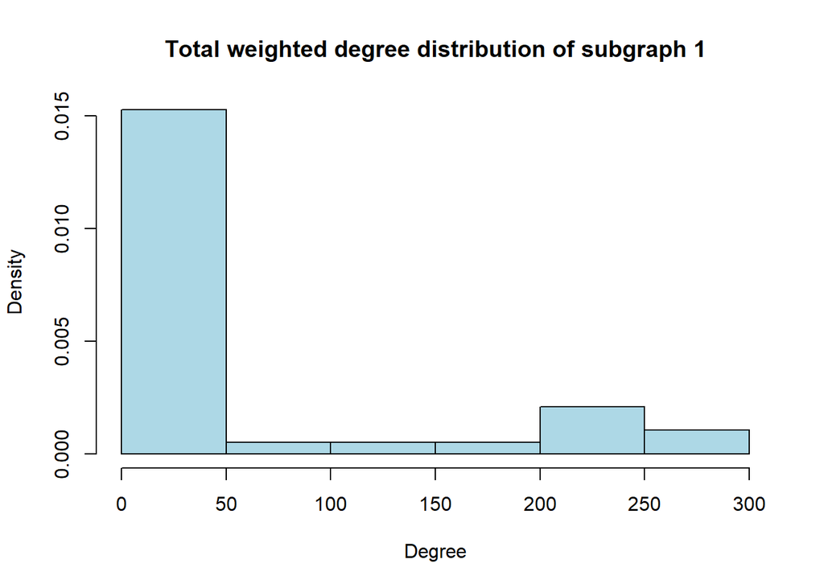

```r
hist(strength(induced.1,mode="total"),
     col="lightblue",
     main="Total weighted degree distribution of subgraph 1",
     xlab="Degree",
     freq=FALSE)
```

Degree distribution with weights

```r
graph_strength_distribution(induced.1)
```

```
##   [1] 0.02631579 0.02631579 0.18421053 0.05263158 0.10526316 0.05263158
##   [7] 0.00000000 0.00000000 0.00000000 0.05263158 0.02631579 0.00000000
##  [13] 0.05263158 0.05263158 0.00000000 0.02631579 0.02631579 0.00000000
##  [19] 0.00000000 0.00000000 0.02631579 0.00000000 0.00000000 0.00000000
##  [25] 0.00000000 0.00000000 0.00000000 0.00000000 0.00000000 0.00000000
##  [31] 0.00000000 0.00000000 0.00000000 0.00000000 0.00000000 0.00000000
##  [37] 0.00000000 0.00000000 0.02631579 0.00000000 0.00000000 0.00000000
##  [43] 0.00000000 0.02631579 0.00000000 0.00000000 0.00000000 0.00000000
##  [49] 0.00000000 0.00000000 0.00000000 0.00000000 0.00000000 0.00000000
##  [55] 0.00000000 0.00000000 0.00000000 0.00000000 0.00000000 0.00000000
##  [61] 0.00000000 0.00000000 0.00000000 0.00000000 0.00000000 0.00000000
##  [67] 0.00000000 0.00000000 0.00000000 0.00000000 0.00000000 0.00000000
##  [73] 0.00000000 0.00000000 0.00000000 0.00000000 0.00000000 0.00000000
##  [79] 0.00000000 0.00000000 0.02631579 0.00000000 0.00000000 0.00000000
##  [85] 0.00000000 0.00000000 0.00000000 0.00000000 0.00000000 0.00000000
```

[output cut: 35 more lines]

- Plot of the distribution with weights

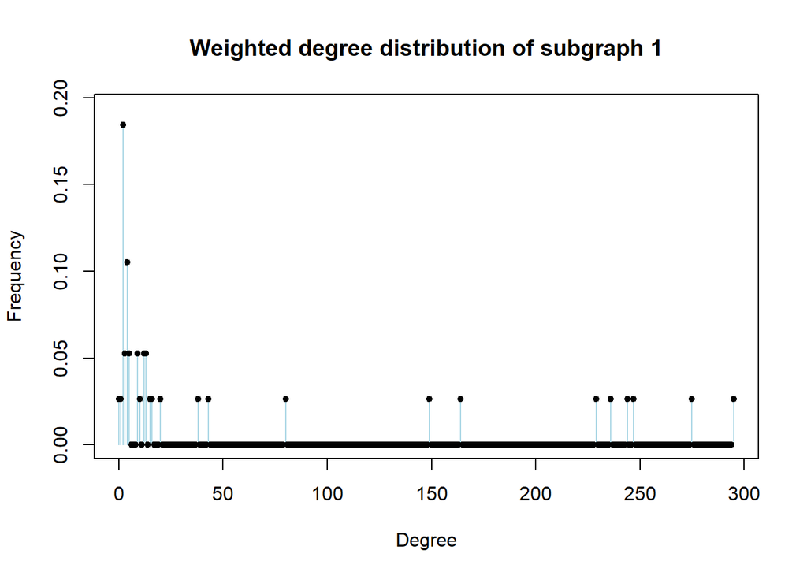

```r
plot(0:max(strength(induced.1)),
     graph_strength_distribution(induced.1),
     ylim=c(0,(max(graph_strength_distribution(induced.1))+0.01)),
     col="lightblue",
     main="Weighted degree distribution of subgraph 1",
     xlab="Degree",
     ylab="Frequency",
     type="h")
points(0:max(strength(induced.1)),
       graph_strength_distribution(induced.1),
       pch=20)
```

Now, if we consider the weights, we see that the sum of the degrees is 2176, which is equivalent of having 1088 scenes between these characters, which represents 52% of the total, consequently, we could say that in this group are consider more characters that have performed a more interactive role, since in the overall we see that this is a smaller number of characters but the total scenes with other characters are very representative.

Additionally, we see that the mean degree is around 57, 20 points higher that for the complete network, and that the distribution is more concetrated in small numbers, being the larger probability of 18% for 2 degrees and the second larger 10% for 4 degrees, but a skewness is generated because of other characters with major appearances.

## Subgraph 2

## Degree

- The degree sequence:

```r
degree(induced.2)
```

```
##                 BB-8              QUI-GON          NUTE GUNRAY
##                    7                   19                   13
##                 PK-4                TC-14               DOFINE
##                    1                    4                    3
##                 RUNE              TEY HOW       CAPTAIN PANAKA
##                    3                    3                    6
##           SIO BIBBLE              JAR JAR              TARPALS
##                    5                   19                    1
##            BOSS NASS                PADME             RIC OLIE
##                    4                   26                    5
##                WATTO              SEBULBA                 JIRA
##                    3                    4                    2
##                 SHMI           DARTH MAUL              KITSTER
##                    5                    3                    6
##                 WALD            FODE/BEED              VALORUM
##                    3                    2                    3
##           MACE WINDU         KI-ADI-MUNDI                 RABE
##                    9                    5                    3
##          BAIL ORGANA         GENERAL CEEL            BRAVO TWO
##                   10                    3                    2
##          BRAVO THREE        CAPTAIN TYPHO      SENATOR ASK AAK
##                    2                    2                    4
##         ORN FREE TAA                 SOLA                JOBAL
##                    2                    3                    3
##                RUWEE              TAUN WE              LAMA SU
##                    3                    2                    1
##           JANGO FETT                 OWEN               CLIEGG
##                    2                    2                    2
##          COUNT DOOKU              SUN RIT               POGGLE
##                    6                    4                    4
##             PLO KOON             ODD BALL     GENERAL GRIEVOUS
##                    1                    0                    1
##             FANG ZAR           MON MOTHMA         GIDDEAN DANU
##                    4                    4                    4
## CLONE COMMANDER GREE CLONE COMMANDER CODY           TION MEDON
##                    0                    1                    0
##        LOR SAN TEKKA                  POE             KYLO REN
##                    4                   11                    8
##       CAPTAIN PHASMA                 FINN          UNKAR PLUTT
##                    5                    9                    2
##                  REY          GENERAL HUX    LIEUTENANT MITAKA
##                    6                    5                    2
##             BALA-TIK                SNOKE                  MAZ
##                    3                    2                    3
##                 SNAP      ADMIRAL STATURA            YOLO ZIFF
##                    4                    3                    4
##        COLONEL DATOO            ELLO ASTY                 JESS
##                    1                    4                    5
##              NIV LEK
##                    4
```

```r
#Check that it is twice the size graph
sum(degree(induced.2))
```

```
## [1] 324
```

- The average degree:

```r
mean(degree(induced.2))
```

```
## [1] 4.438356
```

- Degree distribution

Frquency table

```r
table(degree(induced.2))
```

```
##
##  0  1  2  3  4  5  6  7  8  9 10 11 13 19 26
##  3  7 13 15 14  7  4  1  1  2  1  1  1  2  1
```

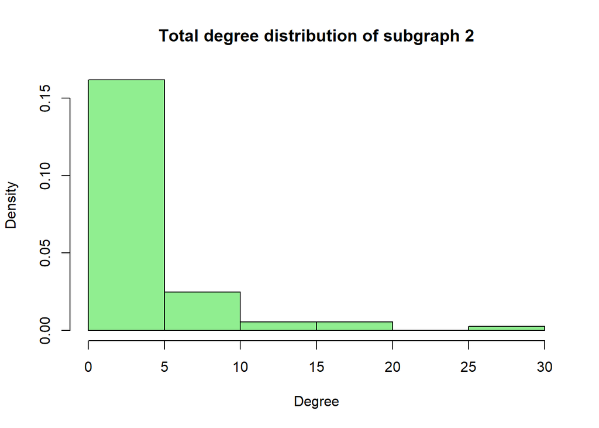

```r
hist(degree(induced.2,mode="total"),
     col="lightgreen",
     main="Total degree distribution of subgraph 2",
     xlab="Degree",
     freq=FALSE)
```

Degree distribution

```r
degree_distribution(induced.2)
```

```
##  [1] 0.04109589 0.09589041 0.17808219 0.20547945 0.19178082 0.09589041
##  [7] 0.05479452 0.01369863 0.01369863 0.02739726 0.01369863 0.01369863
## [13] 0.00000000 0.01369863 0.00000000 0.00000000 0.00000000 0.00000000
## [19] 0.00000000 0.02739726 0.00000000 0.00000000 0.00000000 0.00000000
## [25] 0.00000000 0.00000000 0.01369863
```

- Plot of the distribution

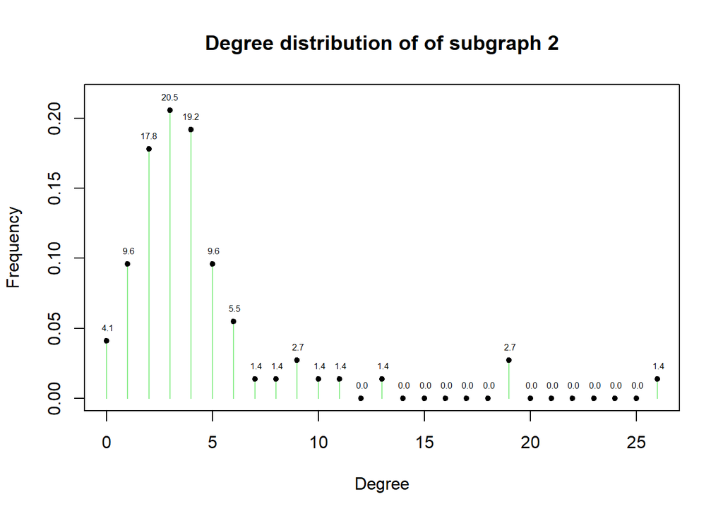

```r
plot(0:max(degree(induced.2)),
     degree_distribution(induced.2),
     ylim=c(0,(max(degree_distribution(induced.2))+0.01)),
     col="lightgreen",
     main="Degree distribution of of subgraph 2",
     xlab="Degree",
     ylab="Frequency",
     type="h")
points(0:max(degree(induced.2)),
       degree_distribution(induced.2),
       pch=20)
text(0:max(degree(induced.2)),
     degree_distribution(induced.2),
     labels=format(100*degree_distribution(induced.2), digits=2), cex=0.5, font=1, pos=3)
```

If we take a look at the second subgroup, we can see that in this prespecified subset of the vertices lay 73 characters which are more than 65% of the total characters, and that created an induced subgraph with 162 edges or the connections among these characters and which represents a total of 36.49% if we consider the total edges on the whole network.

This subgraph presents an averge degree of approximately 4, which is lower that what we got for the complete network (8), as in the case for the first subgroup, this can be attributed to the fact that the connections between the groups are not taken into account, and as we saw in the graphs in this subgroup lay a lot of characters that do not play a major role in these episodes.

If we check the frequency table of the degree distribution we see that the media is 3, and that the maximum number is 26 which corresponds to Padme. Moreover, if we check the accumulated probability that a random vertex has less or equal to five degrees is more than 80%, so there is a higher probability when comparing to the other subgroup, reaffirming that in this group are more characters that did not participate much with other characters.

## Degree with weights

- The degree sequence with weights:

```r
strength(induced.2)
```

```
##                 BB-8              QUI-GON          NUTE GUNRAY
##                   47                   84                   26
##                 PK-4                TC-14               DOFINE
##                    1                    4                    3
##                 RUNE              TEY HOW       CAPTAIN PANAKA
##                   11                    4                   29
##           SIO BIBBLE              JAR JAR              TARPALS
##                    9                   61                    2
##            BOSS NASS                PADME             RIC OLIE
##                    7                   79                   11
##                WATTO              SEBULBA                 JIRA
##                   10                    7                    3
##                 SHMI           DARTH MAUL              KITSTER
##                   18                    5                    7
##                 WALD            FODE/BEED              VALORUM
##                    4                    3                    3
##           MACE WINDU         KI-ADI-MUNDI                 RABE
##                   16                    9                    3
##          BAIL ORGANA         GENERAL CEEL            BRAVO TWO
##                   17                    3                    6
##          BRAVO THREE        CAPTAIN TYPHO      SENATOR ASK AAK
##                    4                    3                    4
##         ORN FREE TAA                 SOLA                JOBAL
##                    2                    4                    4
##                RUWEE              TAUN WE              LAMA SU
##                    3                    3                    2
##           JANGO FETT                 OWEN               CLIEGG
##                    2                    6                    4
##          COUNT DOOKU              SUN RIT               POGGLE
##                    9                    6                    6
##             PLO KOON             ODD BALL     GENERAL GRIEVOUS
##                    1                    0                    1
##             FANG ZAR           MON MOTHMA         GIDDEAN DANU
##                    7                    7                    4
## CLONE COMMANDER GREE CLONE COMMANDER CODY           TION MEDON
##                    0                    1                    0
##        LOR SAN TEKKA                  POE             KYLO REN
##                    7                   36                   19
##       CAPTAIN PHASMA                 FINN          UNKAR PLUTT
##                    7                   65                    3
##                  REY          GENERAL HUX    LIEUTENANT MITAKA
##                   55                   11                    3
##             BALA-TIK                SNOKE                  MAZ
##                    3                    5                    7
##                 SNAP      ADMIRAL STATURA            YOLO ZIFF
##                    5                    3                    4
##        COLONEL DATOO            ELLO ASTY                 JESS
##                    1                    8                    8
##              NIV LEK
##                    7
```

```r
#Check that it is twice the size graph
sum(strength(induced.2))
```

```
## [1] 832
```

- The average degree with weights:

```r
mean(strength(induced.2))
```

```
## [1] 11.39726
```

- Degree distribution with weights

Frquency table with weights

```r
table(strength(induced.2))
```

```
##
##  0  1  2  3  4  5  6  7  8  9 10 11 16 17 18 19 26 29 36 47 55 61 65 79 84
##  3  5  4 13 10  3  4  9  2  3  1  3  1  1  1  1  1  1  1  1  1  1  1  1  1
```

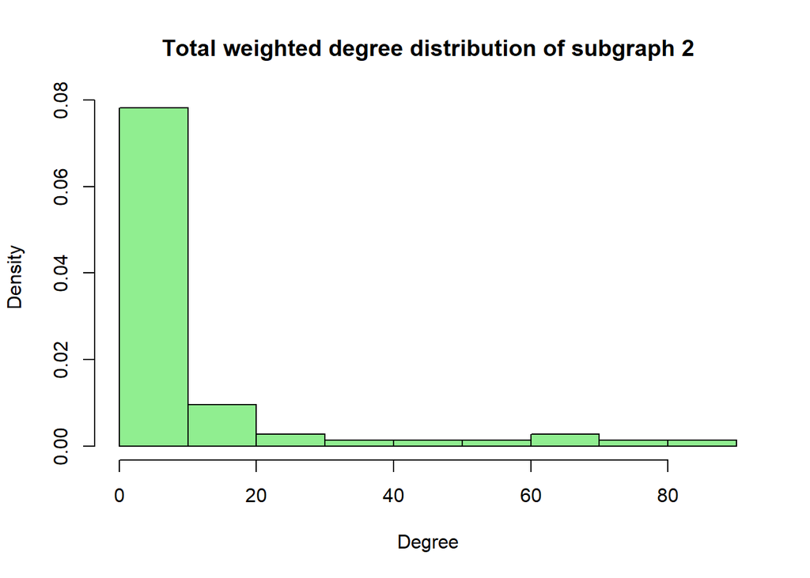

```r
hist(strength(induced.2,mode="total"),
     col="lightgreen",
     main="Total weighted degree distribution of subgraph 2",
     xlab="Degree",
     freq=FALSE)
```

Degree distribution with weights

```r
graph_strength_distribution(induced.2)
```

```
##  [1] 0.04109589 0.06849315 0.05479452 0.17808219 0.13698630 0.04109589
##  [7] 0.05479452 0.12328767 0.02739726 0.04109589 0.01369863 0.04109589
## [13] 0.00000000 0.00000000 0.00000000 0.00000000 0.01369863 0.01369863
## [19] 0.01369863 0.01369863 0.00000000 0.00000000 0.00000000 0.00000000
## [25] 0.00000000 0.00000000 0.01369863 0.00000000 0.00000000 0.01369863
## [31] 0.00000000 0.00000000 0.00000000 0.00000000 0.00000000 0.00000000
## [37] 0.01369863 0.00000000 0.00000000 0.00000000 0.00000000 0.00000000
## [43] 0.00000000 0.00000000 0.00000000 0.00000000 0.00000000 0.01369863
## [49] 0.00000000 0.00000000 0.00000000 0.00000000 0.00000000 0.00000000
## [55] 0.00000000 0.01369863 0.00000000 0.00000000 0.00000000 0.00000000
## [61] 0.00000000 0.01369863 0.00000000 0.00000000 0.00000000 0.01369863
## [67] 0.00000000 0.00000000 0.00000000 0.00000000 0.00000000 0.00000000
## [73] 0.00000000 0.00000000 0.00000000 0.00000000 0.00000000 0.00000000
## [79] 0.00000000 0.01369863 0.00000000 0.00000000 0.00000000 0.00000000
## [85] 0.01369863
```

- Plot of the distribution with weights

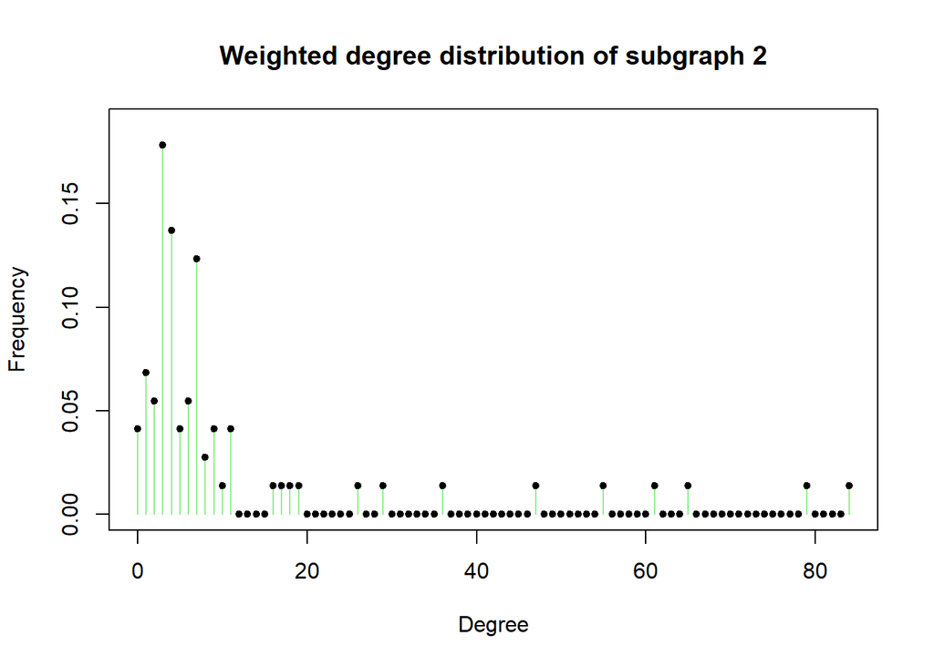

```r
plot(0:max(strength(induced.2)),
     graph_strength_distribution(induced.2),
     ylim=c(0,(max(graph_strength_distribution(induced.2))+0.01)),
     col="lightgreen",
     main="Weighted degree distribution of subgraph 2",
     xlab="Degree",
     ylab="Frequency",
     type="h")
points(0:max(strength(induced.2)),
       graph_strength_distribution(induced.2),
       pch=20)
```

Finally, if we take in consideration the weights or the number of scenes that the characters considered in this subgraph did together, we can see that the sum of degrees is just 832, which is equivalent to just 416 scenes together.

#Check that the network is not a multigraph (Graphs with multiple directed edges #sharing the same vertices)

```r
is_simple(sw.network)
```

```
## [1] TRUE
```

## Random walk of length 5 in the network.

```r
random_walk(sw.network,start=1,steps=5,mode='all',stuck="return")
```

```
## + 5/111 vertices, named, from 0a74ff3:
## [1] DARTH VADER TARKIN      DARTH VADER EMPEROR     DARTH MAUL
```

## Shortest circuit in the network.

```r
girth(sw.network,circle=TRUE)
```

```
## $girth
## [1] 3
##
## $circle
## + 3/111 vertices, named, from 0a74ff3:
## [1] R2-D2       DARTH VADER CHEWBACCA
```

The shortest circuit display involves 3 vertices which in this case correspond to the characters ‘R2-D2’, ‘DARTH VADER’ and ‘CHEWBACCA’

## Check wether the network is connected or not.

```r
is_connected(sw.network)
```

```
## [1] FALSE
```

Every vertex is not reachable from every other, consequently, the network is not connected and there will be characters that did not interact with others on the scenes of these episodes.

## Components of the network.

```r
components(sw.network)
```

```
## $membership
##          DARTH VADER                R2-D2            CHEWBACCA
##                    1                    1                    1
##                 BB-8              QUI-GON          NUTE GUNRAY
##                    1                    1                    1
##                 PK-4                TC-14              OBI-WAN
##                    1                    1                    1
##               DOFINE                 RUNE              TEY HOW
##                    1                    1                    1
##              EMPEROR       CAPTAIN PANAKA           SIO BIBBLE
##                    1                    1                    1
##              JAR JAR              TARPALS            BOSS NASS
##                    1                    1                    1
##                PADME             RIC OLIE                WATTO
##                    1                    1                    1
##              SEBULBA                 JIRA                 SHMI
##                    1                    1                    1
##                C-3PO           DARTH MAUL              KITSTER
##                    1                    1                    1
##                 WALD            FODE/BEED                JABBA
##                    1                    1                    1
##               GREEDO              VALORUM           MACE WINDU
##                    1                    1                    1
##         KI-ADI-MUNDI                 YODA                 RABE
##                    1                    1                    1
##          BAIL ORGANA         GENERAL CEEL            BRAVO TWO
##                    1                    1                    1
##          BRAVO THREE        CAPTAIN TYPHO      SENATOR ASK AAK
##                    1                    1                    1
##         ORN FREE TAA                 SOLA                JOBAL
##                    1                    1                    1
##                RUWEE              TAUN WE              LAMA SU
##                    1                    1                    1
##            BOBA FETT           JANGO FETT                 OWEN
##                    1                    1                    1
##                 BERU               CLIEGG          COUNT DOOKU
##                    1                    1                    1
##              SUN RIT               POGGLE             PLO KOON
##                    1                    1                    1
##             ODD BALL     GENERAL GRIEVOUS             FANG ZAR
```

[output cut: 26 more lines]

```
##                    1                    1                    1
##          GENERAL HUX    LIEUTENANT MITAKA             BALA-TIK
##                    1                    1                    1
##                SNOKE                  MAZ                 SNAP
##                    1                    1                    1
##      ADMIRAL STATURA            YOLO ZIFF        COLONEL DATOO
##                    1                    1                    1
##            ELLO ASTY                 JESS              NIV LEK
##                    1                    1                    1
##
## $csize
## [1] 110   1
##
## $no
## [1] 2
```

By taking a look at the components we can see that there is one character Gold Five which did not do any scene with other characters, then we do not have a single component.

## Diameter, the associated path and the farthest vertices with no weights, as well as for their weighted versions.

```r
get_diameter(sw.network,weights=rep(1,gsize(sw.network)))
```

```
## + 7/111 vertices, named, from 0a74ff3:
## [1] DOFINE        NUTE GUNRAY   DARTH VADER   CHEWBACCA     KYLO REN
## [6] GENERAL HUX   COLONEL DATOO
```

```r
diameter(sw.network,weights=rep(1,gsize(sw.network)))
```

```
## [1] 6
```

```r
farthest_vertices(sw.network,weights=rep(1,gsize(sw.network)))
```

```
## $vertices
## + 2/111 vertices, named, from 0a74ff3:
## [1] DOFINE        COLONEL DATOO
##
## $distance
## [1] 6
```

```r
get_diameter(sw.network)
```

```
## + 9/111 vertices, named, from 0a74ff3:
## [1] RUNE         DARTH MAUL   GENERAL CEEL NUTE GUNRAY  OBI-WAN
## [6] LEIA         BIGGS        WEDGE        JANSON
```

```r
diameter(sw.network)
```

```
## [1] 10
```

```r
farthest_vertices(sw.network)
```

```
## $vertices
## + 2/111 vertices, named, from 0a74ff3:
## [1] RUNE   JANSON
##
## $distance
## [1] 10
```

The diameter will be the longest geodesic distance in the network, in this case if we do not take in account the weights or the ammount of scenes that the characters did together, we get that this corresponds to a diameter of 6, the path extracted shows the vertices involve correspond to:

1. DOFINE
2. NUTE GUNRAY
3. DARTH VADER
4. CHEWBACCA
5. KYLO REN
6. GENERAL HUX
7. COLONEL DATOO

Being the farthest vertices (1) and (7).

On the other side, if we take the diameter by weighting edges we get that this corresponds to 10, the path showed the characters:

1. RUNE
2. DARTH MAUL
3. GENERAL CEEL
4. NUTE GUNRAY
5. OBI-WAN
6. LEIA
7. BIGGS
8. WEDGE
9. JANSON

Where the farthest vertices are (1) and (9)